# Part II - Data Findings

## by Lan Nguyen

## Investigation Overview

This investigation analyzes data from the Prosper lending platform, focusing on key features like loan terms, APR, Prosper Scores, employment statuses, borrower categories, loan statuses, and purposes. Initial steps involve data cleaning and refining. Univariate analysis examines feature distributions and prevalence. Bivariate analysis explores relationships between borrower attributes and lending outcomes. Multivariate analysis delves into complex interactions between Prosper Scores, APR, loan terms, and employment statuses. Overall, this investigation aims to uncover insights into borrowing trends, risk assessment, and lending dynamics within the Prosper platform.

## Dataset Overview

The dataset comprises 83,982 loans encompassing 21 attributes, which include variables like LoanOriginalAmount, BorrowerAPR, StatedMonthlyIncome, ProsperRating (Alpha), EmploymentStatus, and various others.

## What can be observed about the distribution of Annual Percentage Rates (APRs)?

- The distribution of Annual Percentage Rate (APR) appears to be multimodal. There are small peaks centered around 0.1 and 0.3, a larger peak centered around 0.2, and a distinct, sharp peak between 0.35 and 0.36. It is worth noting that only a very few loans have APR values greater than 0.43.

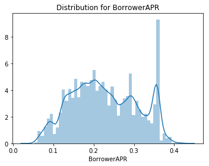

## What key trends are observed in loan status, employment status, borrower categories, and loan purposes among the applicants?

- Loan Status: The majority of borrowers are diligently repaying their loans, as most of the loans are marked as "current." Additionally, a significant number of loans have been successfully completed, indicating a positive track record of loan fulfillment.
- Employment Status: A substantial 80% of borrowers are employed, highlighting a reliable and stable source of income among the applicants. This factor contributes to the lenders' confidence in the borrowers' ability to repay the loans.
- Borrower Categories: The two largest borrower groups are individuals classified as "other" and "professional." On the contrary, students represent the smallest segment among the borrower categories, suggesting that the loan applicants are primarily working professionals.
- Loan Purposes: Debt consolidation emerges as the most prevalent reason for borrowing, indicating that many borrowers seek to manage and streamline their existing debts. Conversely, loan applications for cosmetic procedures, baby adoption, and engagement rings are relatively infrequent, suggesting that these specific purposes are less common motivations for taking out loans.

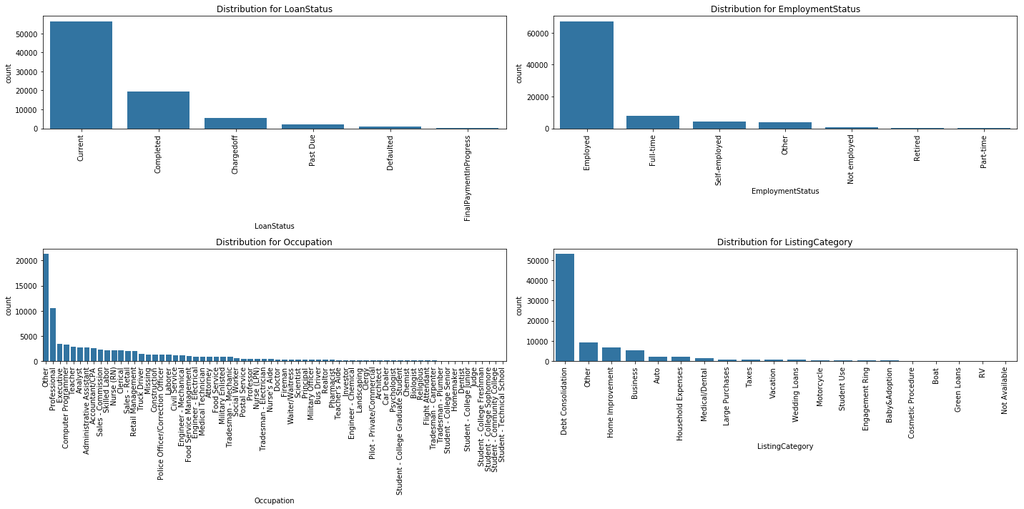

## How have loan listing trends changed over time, and what patterns can be observed in loan application periods throughout the year?

- Over the years, the number of listings has shown a consistent upward trend, except for the year 2014, where complete data is not available. This growth in listings indicates a growing demand for loans over time.
- The loan applications tend to cluster around specific periods within each year. We observe higher activity in the beginning of the year, particularly in January and February, possibly indicating a higher need for financial assistance after the holiday season. Additionally, there is another surge in loan applications during the last half of the year, from September to December. This pattern could be attributed to various factors, such as year-end expenses, holiday preparations, or financial planning for the upcoming new year.

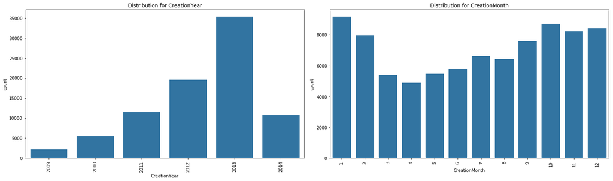

## Which borrower ocuppaction show the highest and lowest Borrower APR?

- Among different borrower categories, College Sophomores who are students have the highest Borrower APR, indicating that they generally face higher interest rates on their loans. Following closely are Teacher's Aides and Homemakers, who also tend to have relatively higher APRs.
- On the other hand, borrowers categorized as Student - Technical School have the lowest Borrower APR, implying that they typically enjoy more favorable interest rates on their loans. Additionally, Judges and Doctors are among the borrower categories with comparably lower APRs.

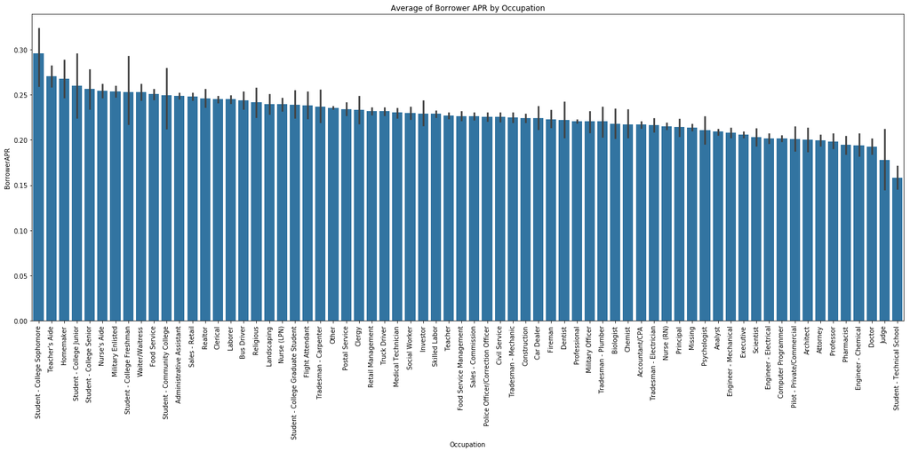

## Which borrower occupation show the highest and lowest Prosper Scores?

- Surprisingly, borrowers categorized as Student - Technical School exhibit the highest Prosper Scores, indicating that they are perceived as more creditworthy and financially stable. Following closely are Judges and Engineers - Chemical, who also have relatively high Prosper Scores.
- Conversely, borrowers identified as Student - College Sophomores have the lowest Prosper Scores, suggesting that they might be perceived as having a higher risk profile. Next in line are Realtors and individuals in the Landscaping industry, who also have comparatively lower Prosper Scores.

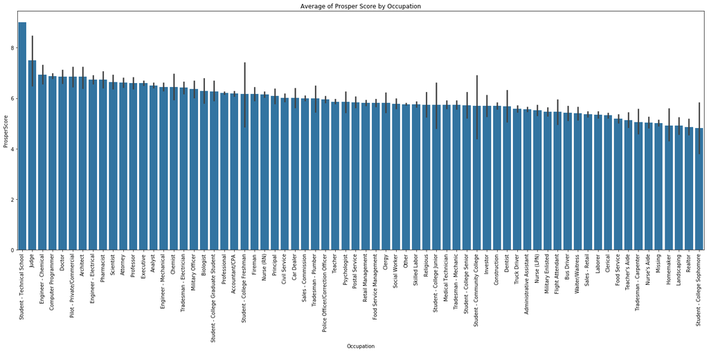

## How does employment status relate to Prosper Scores and Borrower APRs?

The observations highlight the impact of employment status on both Prosper Scores and Borrower APRs, indicating that employment plays a crucial role in loan assessments and interest rate determination.

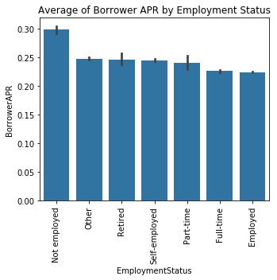

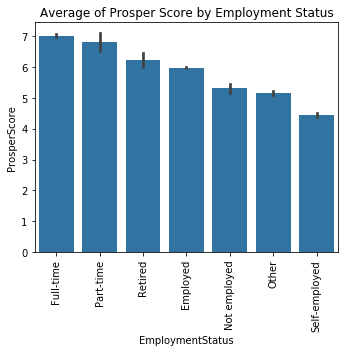

## How do Prosper Scores and Borrower APRs interrelate for each term?

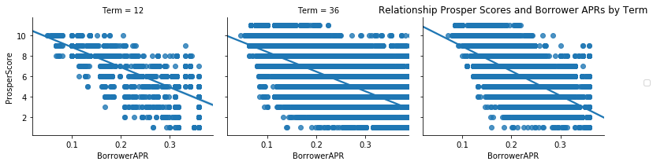